## Assignment 10 Solutions

#### Due Friday, November 13, 11:59 PM CT

### 1

> Summarize the Geissler data set for families of size of 5 (which is the distribution of boys and girls among the first five children in families with six or more children in Saxony over the time period) with the following calculations: find the number of families, total number of children, number of boys (sex assigned at birth), number of girls, the proportion of each, and the observed sex ratio (boys per 100 girls).

### Solution

```r
geissler = read_csv("../../data/geissler.csv")

g5 = geissler %>%
  filter(size == 5)

g5_sum = g5 %>%
  summarize(families = sum(freq),
            children = 5*families,
            boys = sum(boys*freq),
            girls = sum(girls*freq),
            p_boy = boys/children,
            p_girl = girls/children,
            sex_ratio = 100*boys/girls)

g5_sum
```

```
## # A tibble: 1 x 7
##   families children   boys  girls p_boy p_girl sex_ratio
##      <dbl>    <dbl>  <dbl>  <dbl> <dbl>  <dbl>     <dbl>
## 1    95390   476950 245215 231735 0.514  0.486      106.
```

### 2

> Fit the simple binomial and beta-binomial models to this data for the number of boys in the family using maximum likelihood. Describe how the assumptions between the two models differ, and how to interpret what this difference implies about the distributions of the numbers of boys and girls among the first five children in this population. Report all parameter estimates for each model and the log-likelihood of each model.

### Solution

- Fit the models

```r
## Binomial model
## Might as well write a function!
mlebinom = function(x)
{
  n = length(x) - 1
  v = 0:n
  p = sum(v*x)/sum(n*x)
  logl = sum( x * dbinom(v, n, p, log=TRUE) )
  dat = tibble(
    phat = p,
    logl = logl
  )
  return ( dat )
}

g5_binom = mlebinom(g5$freq)

g5_binom
```

```
## # A tibble: 1 x 2
##    phat     logl
##   <dbl>    <dbl>
## 1 0.514 -146591.
```

```r
## Beta-Binomial model
g5_bb = mlebb(g5$freq)

g5_bb
```

```
## # A tibble: 1 x 6
##      mu   phi alpha  beta     logl convergence
##   <dbl> <dbl> <dbl> <dbl>    <dbl>       <int>
## 1 0.514  138.  71.1  67.2 -146566.           0
```

> Describe how the assumptions between the two models differ, and how to interpret what this difference implies about the distributions of the numbers of boys and girls among the first five children in this population.

The binomial model assumes each single birth has the same probability of being a boy.

The beta-binomial model assumes that probabilities of boys are the same within families, but that this probability varies across families, distributed with a beta distribution.

> Report all parameter estimates for each model and the log-likelihood of each model.

```r
## binomial
g5_binom
```

```
## # A tibble: 1 x 2
##    phat     logl
##   <dbl>    <dbl>
## 1 0.514 -146591.
```

```r
##beta-binomial
g5_bb
```

```
## # A tibble: 1 x 6
##      mu   phi alpha  beta     logl convergence
##   <dbl> <dbl> <dbl> <dbl>    <dbl>       <int>
## 1 0.514  138.  71.1  67.2 -146566.           0
```

### 3

> Using results from the previous problem, test the null hypothesis of the binomial model versus the alternative hypothesis of the beta-binomial model. Report a test statistic, the sampling distribution of the test statistic assuming the null hypothesis is true, and a numerical estimate of the p-value. Interpret the results of this hypothesis text in context. For the fitted beta-binomial model, graph the beta density using the estimated parameter values. Interpret the meaning of this graph in context.

### Solution

> Using results from the previous problem, test the null hypothesis of the binomial model versus the alternative hypothesis of the beta-binomial model. Report a test statistic, the sampling distribution of the test statistic assuming the null hypothesis is true, and a numerical estimate of the p-value.

```r
## test statistic
lrt = 2 * (g5_bb$logl - g5_binom$logl)
lrt
```

```
## [1] 48.40527
```

```r
## p-value
1 - pchisq(lrt,1)
```

```
## [1] 3.466338e-12
```

- The test statistic is 48.4.
- Under the null hypothesis, the test statistic has a chi-square(1) distribution.
- The p-value is less than $4\times 10^{-12}$.

> Interpret the results of this hypothesis text in context.

There is strong evidence of heterogeneity in the probability of the sexes of children in different families in Saxony during the time period relative to a model with assumes these probabilities are all equal ($p < 4\times 10^{-12}$, likelihood ratio test, LRT = 48.4, df = 1).

> For the fitted beta-binomial model, graph the beta density using the estimated parameter values. Interpret the meaning of this graph in context.

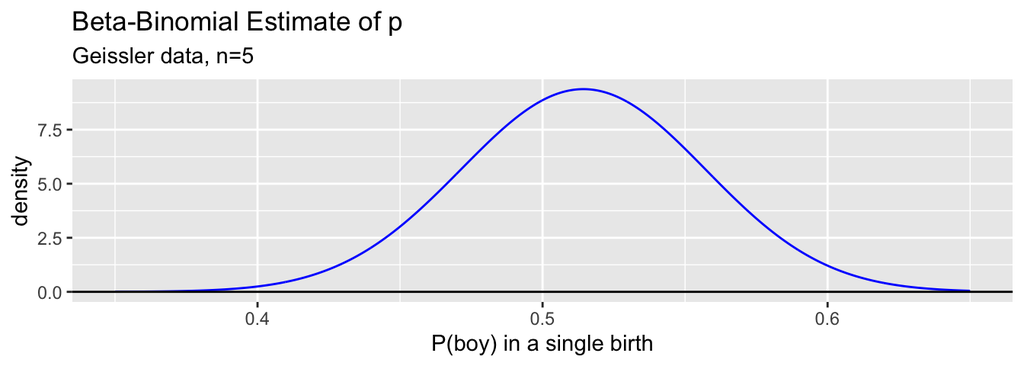

```r
gbeta(g5_bb$alpha, g5_bb$beta, a = 0.35, b = 0.65) +
  ggtitle("Beta-Binomial Estimate of p",
          subtitle = "Geissler data, n=5") +
  xlab("P(boy) in a single birth")
```

- There is evidence of variation in the probability of having a boy among families in Saxony at the time of the study.
- Probabilities tend to vary from a low of a bit over 0.4 to a high around 0.63, give or take.

### 4

> Using the French family data in the file *french-children.csv*, make the following calculations.

> Be sure to read the *Course Notes* description of the data as the format is different than the Geissler data. Specifically, each row specifies the number of families (in 1000s) with a child born given the previous number of boys and girls in the family, and the proportion of boys among those children. Each new child is only counted once and each family will appear each time there is a new child added.
- Find the total number of families, boys, girls, children, and average number of children per family.
- Find the proportion of boys, the proportion of girls, and the sex ratio (# of boys per 100 girls, sexes assigned at birth).
- Determine the number of children for each birth order (first, second, third, and so on) in the data set and count the number of boys and girls in each.
- Calculate the proportion of girls for each birth order and plot these proportions by birth order. Use the size attribute to signify the number of children.
  - Is there a pattern in this data?

### Solution

```r
## Read data
## Add some useful columns
france = read_csv("../../data/french-children.csv") %>%
  mutate(birth_order = boys + girls + 1,
         children = 1000*count,
         n_boys = round(children*p_boy),
         n_girls = round(children*(1 - p_boy)),
         )
```

> Find the total number of families, boys, girls, children, and average number of chidren per family.

```r
france_1 = france %>%
  summarize(families = sum(children[birth_order == 1]),
            boys = sum(n_boys),
            girls = sum(n_girls),
            children = boys + girls,
            children_per_family = children / families)

france_1
```

```
## # A tibble: 1 x 5
##   families    boys   girls children children_per_family
##      <dbl>   <dbl>   <dbl>    <dbl>               <dbl>
## 1  1499000 1985309 1882691  3868000                2.58
```

> Find the proportion of boys, the proportion of girls, and the sex ratio (# of boys per 100 girls, sexes assigned at birth).

```r
france_2 = france_1 %>%
  summarize(p_boy = boys / children,
            p_girl = girls / children,
            sex_ratio = 100 * boys / girls)

france_2
```

```
## # A tibble: 1 x 3
##   p_boy p_girl sex_ratio
##   <dbl>  <dbl>     <dbl>
## 1 0.513  0.487      105.
```

> Determine the number of children for each birth order (first, second, third, and so on) in the data set and count the number of boys and girls in each.

```r
france_3 = france %>%
  group_by(birth_order) %>%
  summarize(children = sum(children),
            boys = sum(n_boys),
            girls = sum(n_girls))

france_3
```

```
## # A tibble: 11 x 4
##    birth_order children   boys  girls
##          <dbl>    <dbl>  <dbl>  <dbl>
##  1           1  1499000 771086 727914
##  2           2  1058000 543775 514225
##  3           3   595000 305549 289451
##  4           4   303000 154497 148503
##  5           5   164000  83588  80412
##  6           6    96000  48908  47092
##  7           7    63000  32228  30772
##  8           8    40000  20348  19652
##  9           9    26000  13029  12971
## 10          10    16000   8224   7776
## 11          11     8000   4077   3923
```

> Calculate the proportion of girls for each birth order and plot these proportions by birth order. Use the size attribute to signify the number of children. Is there a pattern in this data?

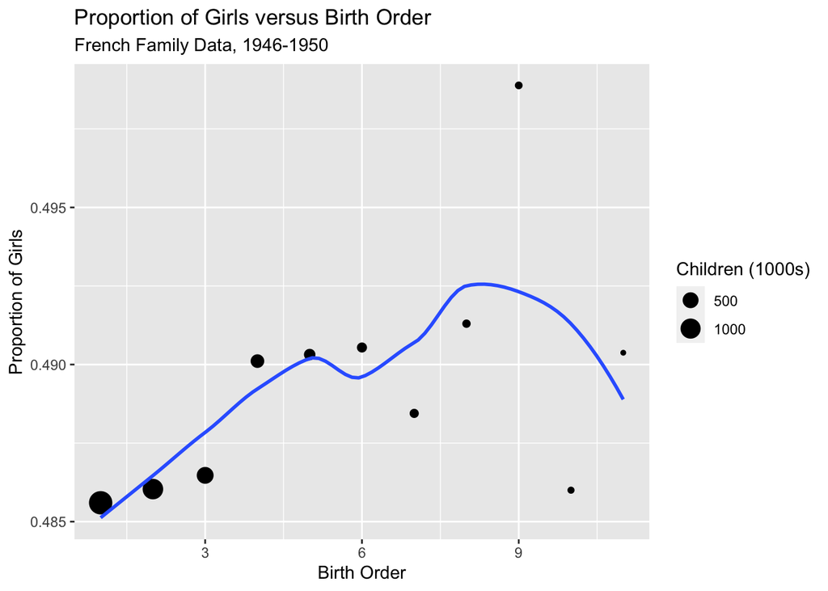

```r
france_3 %>%
  mutate(p_girl = girls / children) %>%
ggplot(aes(x = birth_order, y = p_girl, size = children/1000)) +
  geom_point() +
  geom_smooth(se=FALSE, show.legend=FALSE) +
  xlab("Birth Order") +
  ylab("Proportion of Girls") +
  ggtitle("Proportion of Girls versus Birth Order",
          subtitle = "French Family Data, 1946-1950") +
  ## Note how to get rid of the annoying line that covers the points
  ##  and how to change the legend title
  guides(size = guide_legend(override.aes = list(linetype = 0),
                             title = "Children (1000s)"))
```

- There seems to be an increasing number of girls as the birth order increases (which is the opposite of what I expected).
- There is more variation as the birth order increases, but this is simply due to the number of total children being much smaller.

### 5

> Using the French family data in the file *french-children.csv*, make the following calculations.
- Determine the number of families with each number of children represented in the data and report these results in a table.
  - The table will have two columns, one for the number of children and one for the number of families with that number of children.
- Create a table with the same structure as the Geissler data with columns `boys`, `girls`, `size`, and `n` so that each row counts the number of families (`n`) in the data set with that number of boys and girls, where size is the number of children in the family. Display the subset of the table for all cases where the number of boys and girls are the same.
  - *(Hint: This last part is tricky. For example, the number of families with exactly 2 boys and 2 girls IS EQUAL TO the number of families who had a boy as the 4th child when they previously had one boy and two girls PLUS the number of families who had a girl as the fourth child when they previously had two boys and one girl MINUS the number of families that previously had two boys and two girls that had another child. A for loop may come in handy.)*

### Solution

> Determine the number of families with each number of children represented in the data and report these results in a table.
- The number of families of size one is the number of families with a first child minus the number with a second child, and so on.

```r
france_4 = france_3 %>%
  mutate(families = -diff(c(children,0))) %>%
  select(birth_order, families) %>%
  rename(size = birth_order)

france_4 %>%
  print(n=Inf)
```

```
## # A tibble: 11 x 2
##     size families
##    <dbl>    <dbl>
##  1     1   441000
##  2     2   463000
##  3     3   292000
##  4     4   139000
##  5     5    68000
##  6     6    33000
##  7     7    23000
##  8     8    14000
##  9     9    10000
## 10    10     8000
## 11    11     8000
```

```r
## Check average number of children is the same
france_4 %>% summarize(avg_children = sum(size*families)/sum(families))
```

```
## # A tibble: 1 x 1
##   avg_children
##          <dbl>
## 1         2.58
```

> Create a table with the same structure as the Geissler data with columns `boys`, `girls`, `size`, and `n` so that each row counts the number of families (`n`) in the data set with that number of boys and girls, where size is the number of children in the family.

```r
france_5 = geissler %>%
  select(boys,girls) %>%
#  filter(boys < 8 & girls < 8) %>%
  mutate(size = boys + girls,
         n = 0)

for ( i in 1:nrow(france_5) )
{
  b = france_5$boys[i]
  g = france_5$girls[i]

  temp1 = france %>% filter(boys == (b-1) & girls == g ) %>% pull(n_boys)
  temp2 = france %>% filter(boys == b & girls == (g-1) ) %>% pull(n_girls)
  temp3 = france %>% filter(boys == b & girls == g) %>% pull(children)

  n = 0

  if ( length(temp1) > 0 )
    n = n + temp1
  if ( length(temp2) > 0 )
    n = n + temp2
  if ( length(temp3) > 0 )
    n = n - temp3

  france_5$n[i] = n
}

france_5 = france_5 %>%
  filter(n > 0)
```

> Display the subset of the table for all cases where the number of boys and girls are the same.

```r
france_5 %>%
  filter(boys == girls)
```

```
## # A tibble: 5 x 4
##    boys girls  size      n
##   <dbl> <dbl> <dbl>  <dbl>
## 1     1     1     2 233131
## 2     2     2     4  49439
## 3     3     3     6  10197
## 4     4     4     8   2945
## 5     5     5    10   1980
```

### 6

> Using the data set of single-birth French families, determine for families with `b` boys and `g` girls the proportion of families which have a subsequent child. This will be a table with columns `boys`, `girls`, and a column for the proportion. Display a subset of these proportions in a reshaped table with one row for the number of previous girls and one column for the number of previous boys. (Some cells will have missing data). Do you agree or disagree with this statement: families with more boys than girls are more likely to continue to have additional children. Use evidence from the displayed table to justify your response.

### Solution

- The proportion we seek is the ratio of the number of families with $b$ boys and $g$ girls that have another child divided by the total number of such families.
- The numerator is the 1000 times the column `count` in the original data.
- The variable `n` in the solution to problem 5 counts the number of families that have no more children.
- So, the denominator is the sum of these two values.
- Join the tables using the number of boys and girls.
- Then, reshape part of the data.

```r
france_6a = france %>%
  select(girls, boys, children)

france_6b = france_5 %>%
  select(-size)

france_6 = inner_join(france_6a, france_6b) %>%
  mutate(p_additional_child = children / (children + n))

france_7 = france_6 %>%
  select(girls, boys, p_additional_child) %>%
#  filter(girls < 5 & boys < 5) %>%
  pivot_wider(names_from = boys, values_from = p_additional_child) %>%
  select(girls, `0`, everything())

france_7
```

```
## # A tibble: 7 x 8
##   girls    `0`   `1`   `2`   `3`   `4`    `5`    `6`
##   <dbl>  <dbl> <dbl> <dbl> <dbl> <dbl>  <dbl>  <dbl>
## 1     0 NA     0.716 0.569 0.524 0.550  0.566  0.935
## 2     1  0.695 0.554 0.506 0.538 0.562  0.682  0.640
## 3     2  0.571 0.503 0.548 0.590 0.652  0.633  0.596
## 4     3  0.523 0.534 0.600 0.651 0.647  0.673  0.666
## 5     4  0.533 0.581 0.609 0.702 0.731  0.715  0.750
## 6     5  0.580 0.703 0.633 0.709 0.728  0.602 NA
## 7     6  0.650 0.564 0.753 0.664 0.507 NA     NA
```

The statement is not fully justified from the data. There are many values to compare, potentially.

- Among families with only one child, the proportion that have another child is:
  - 71.6% if they already have a boy;
  - 69.5% if they already have a girl.
  - The difference is about 2% higher for those families with a single boy.
- Among families with two children, the proportion that have another child is:
  - 56.9% if they already have two boys;
  - 55.4% if they already have one boy and one girl;
  - 57.1% if they already have two girls.
  - Families with one child of each sex are about 1.5% less likely to have another child than if both children are the sme sex.
  - The difference between those with two boys or two girls is small, only 0.2%.
- Among families with three children, the proportion that have another child is:
  - 52.4% if they already have three boys;
  - 50.6% if they already have two boys and one girl;
  - 50.3% if they already have two girls and one boy;
  - 52.3% if they already have three girls.
- We could continue to make comparisons for larger families, but the total number of such families is much smaller so that observed differenes are more likely to be affected by small samples.
- We are missing data from families with all or almost all children of the same sex for families with 7 or more children.

There is a slight trend that families with only one boy are slightly more likely to have another child than those with only one girl, but the differences are very small for families with two and three children.

The larger trend, perhaps, is that families with all children of the same sex are more likely to have an additional child than families with a mix of boys and girls.